# K-fold Factor Analysis - Example Sim

November 02, 2021

# Overview

**# of folds:** 4

**# of variables:** 20

**# of observations:** 900

**Maximum # of factors:**

- Allowed - 5
- Extracted - 3

**Estimation:** ML

**Missing Data:** listwise

# Model Summary

**Fit across folds by factor model**

| model | df | chisq mean | chisq range | cfi mean | cfi range | rmsea mean | rmsea range |
| --- | --- | --- | --- | --- | --- | --- | --- |
| 1-factor | 170 | 467.64 | 399.25 - 522.77 | 0.51 | 0.42 - 0.61 | 0.09 | 0.08 - 0.10 |
| 2-factor | 169 | 334.77 | 302.03 - 357.22 | 0.73 | 0.66 - 0.77 | 0.07 | 0.06 - 0.07 |
| 3-factor | 167 | 172.47 | 142.19 - 193.97 | 0.98 | 0.95 - 1.00 | 0.01 | 0.00 - 0.03 |
| custom2f | 169 | 353.28 | 312.77 - 409.98 | 0.69 | 0.56 - 0.76 | 0.07 | 0.06 - 0.08 |

**Count of folds out of 4 with flagged problems**

| model | mode structure | improper solution | heywood item | low loading | high factor correlation | low scale reliability |
| --- | --- | --- | --- | --- | --- | --- |
| 1-factor | 4 | 0 | 0 | 4 |  | 1 |
| 2-factor | 3 | 0 | 0 | 3 | 0 | 1 |
| 3-factor | 4 | 0 | 0 | 3 | 0 | 0 |
| custom2f | 4 | 0 | 0 | 4 | 0 | 1 |

# Model Details

## 1-factor

**Factor Structure**

f1 =~ x1 + x2 + x3 + x4 + x5 + x6 + x7 + x8 + x9 + x10 + x11 + x12 + x13 + x14 + x15 + x16 + x17 + x18 + x19 + x20

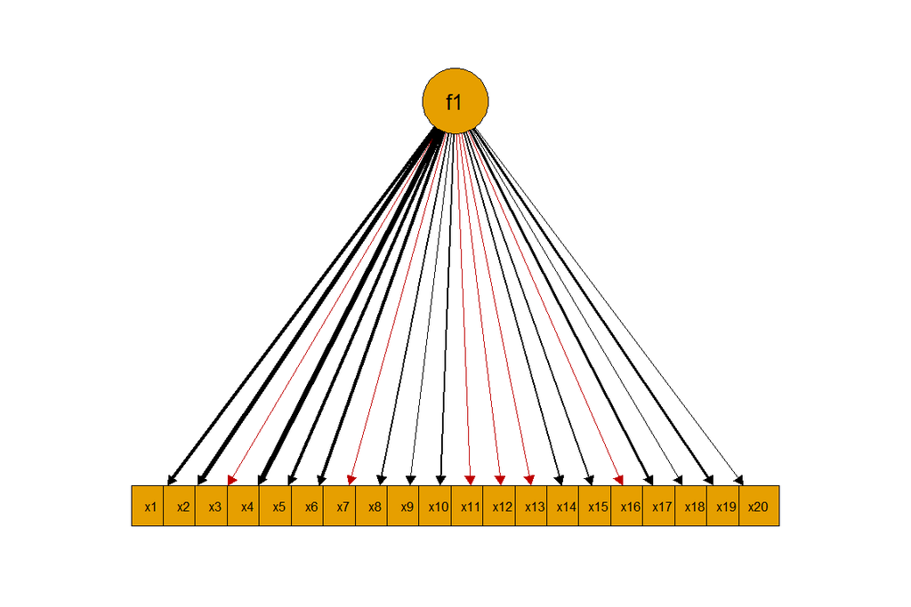

**Standardized Loading Across Folds**

| variable | mean | range | loading flag | heywood flag |
| --- | --- | --- | --- | --- |
| x1 | 0.53 | 0.26 - 0.66 | 1 | 0 |
| x2 | 0.50 | 0.38 - 0.75 | 0 | 0 |
| x3 | 0.34 | 0.30 - 0.43 | 0 | 0 |
| x4 | 0.31 | 0.16 - 0.45 | 2 | 0 |
| x5 | 0.47 | 0.32 - 0.62 | 0 | 0 |
| x6 | 0.41 | 0.38 - 0.47 | 0 | 0 |
| x7 | 0.26 | 0.09 - 0.40 | 2 | 0 |
| x8 | 0.21 | 0.08 - 0.31 | 3 | 0 |
| x9 | 0.41 | 0.24 - 0.56 | 1 | 0 |
| x10 | 0.18 | 0.00 - 0.32 | 3 | 0 |
| x11 | 0.34 | 0.17 - 0.50 | 2 | 0 |
| x12 | 0.62 | 0.30 - 0.84 | 1 | 0 |
| x13 | 0.28 | 0.03 - 0.40 | 1 | 0 |
| x14 | 0.20 | 0.07 - 0.32 | 3 | 0 |
| x15 | 0.48 | 0.11 - 0.77 | 1 | 0 |
| x16 | 0.44 | 0.16 - 0.62 | 1 | 0 |
| x17 | 0.47 | 0.16 - 0.65 | 1 | 0 |
| x18 | 0.23 | 0.04 - 0.34 | 3 | 0 |
| x19 | 0.52 | 0.37 - 0.69 | 0 | 0 |
| x20 | 0.56 | 0.39 - 0.90 | 0 | 0 |

Note: loadings flagged when < 0.3 in a fold. ‘heywood flag’ is the number of folds the variable’s estimated residual variance was negative

**Scale Reliability Across Folds**

| factor | omega_h mean | omega_h range | omega_h flag | alpha mean | alpha range | alpha flag |
| --- | --- | --- | --- | --- | --- | --- |
| f1 | 0.73 | 0.67 - 0.77 | 0 | 0.66 | 0.45 - 0.75 | 1 |

Note: ‘flag’ is the number of folds the scale had a reliability < 0.6

## 2-factor

**Factor Structure**

f1 =~ x1 + x2 + x3 + x4 + x5 + x6 + x7 + x8 + x9 + x10 + x11 + x12 + x13 + x14

f2 =~ x15 + x16 + x17 + x18 + x19 + x20

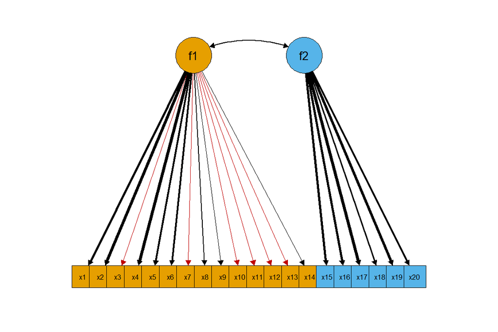

**Standardized Loading Across Folds**

| variable | mean | range | loading flag | heywood flag |
| --- | --- | --- | --- | --- |
| x1 | 0.54 | 0.25 - 0.70 | 1 | 0 |
| x2 | 0.51 | 0.34 - 0.76 | 0 | 0 |
| x3 | 0.30 | 0.27 - 0.32 | 1 | 0 |
| x4 | 0.35 | 0.26 - 0.46 | 1 | 0 |
| x5 | 0.46 | 0.28 - 0.64 | 1 | 0 |
| x6 | 0.40 | 0.36 - 0.46 | 0 | 0 |
| x7 | 0.65 | 0.58 - 0.71 | 0 | 0 |
| x8 | 0.54 | 0.46 - 0.66 | 0 | 0 |
| x9 | 0.89 | 0.84 - 0.94 | 0 | 0 |
| x10 | 0.43 | 0.42 - 0.44 | 0 | 0 |
| x11 | 0.72 | 0.64 - 0.77 | 0 | 0 |
| x12 | 0.64 | 0.27 - 0.95 | 1 | 0 |
| x13 | 0.50 | 0.38 - 0.59 | 0 | 0 |
| x14 | 0.17 | 0.07 - 0.30 | 3 | 0 |
| x15 | 0.45 | 0.09 - 0.81 | 1 | 0 |
| x16 | 0.41 | 0.15 - 0.57 | 1 | 0 |
| x17 | 0.46 | 0.15 - 0.70 | 1 | 0 |
| x18 | 0.21 | 0.03 - 0.30 | 2 | 0 |
| x19 | 0.56 | 0.45 - 0.70 | 0 | 0 |
| x20 | 0.59 | 0.40 - 0.90 | 0 | 0 |

Note: loadings flagged when < 0.3 in a fold. ‘heywood flag’ is the number of folds the variable’s estimated residual variance was negative

**Mean Factor Correlations**

|  | f1 | f2 | flag |
| --- | --- | --- | --- |
| f1 | 1.00 |  | 0 |
| f2 | 0.24 | 1.00 | 0 |

Note: ‘flag’ is the number of folds the factor had a correlation > 0.9

**Scale Reliability Across Folds**

| factor | omega_h mean | omega_h range | omega_h flag | alpha mean | alpha range | alpha flag |
| --- | --- | --- | --- | --- | --- | --- |
| f1 | 0.71 | 0.67 - 0.74 | 0 | 0.65 | 0.52 - 0.72 | 1 |
| f2 | 0.70 | 0.65 - 0.74 | 0 | 0.71 | 0.66 - 0.75 | 0 |

Note: ‘flag’ is the number of folds the scale had a reliability < 0.6

## 3-factor

**Factor Structure**

f1 =~ x1 + x2 + x3 + x4 + x5 + x6 + x7

f2 =~ x15 + x16 + x17 + x18 + x19 + x20

f3 =~ x8 + x9 + x10 + x11 + x12 + x13 + x14

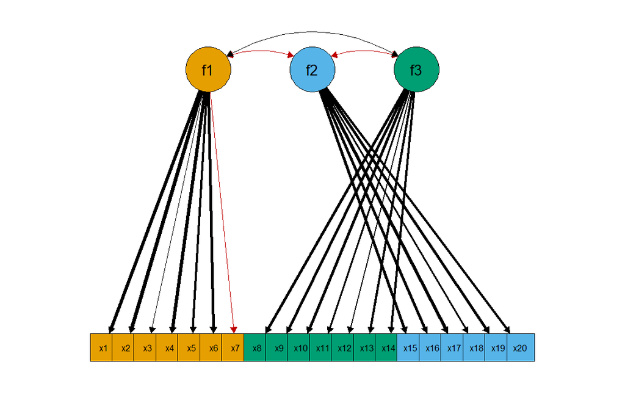

**Standardized Loading Across Folds**

[output not shown]

Note: loadings flagged when < 0.3 in a fold. ‘heywood flag’ is the number of folds the variable’s estimated residual variance was negative

**Mean Factor Correlations**

|  | f1 | f2 | f3 | flag |
| --- | --- | --- | --- | --- |
| f1 | 1.00 |  |  | 0 |
| f2 | 0.24 | 1.00 |  | 0 |
| f3 | 0.28 | 0.21 | 1.00 | 0 |

Note: ‘flag’ is the number of folds the factor had a correlation > 0.9

**Scale Reliability Across Folds**

| factor | omega_h mean | omega_h range | omega_h flag | alpha mean | alpha range | alpha flag |
| --- | --- | --- | --- | --- | --- | --- |
| f1 | 0.71 | 0.66 - 0.74 | 0 | 0.72 | 0.67 - 0.75 | 0 |
| f2 | 0.69 | 0.65 - 0.74 | 0 | 0.70 | 0.66 - 0.75 | 0 |
| f3 | 0.71 | 0.68 - 0.72 | 0 | 0.71 | 0.68 - 0.73 | 0 |

Note: ‘flag’ is the number of folds the scale had a reliability < 0.6

## custom2f

**Factor Structure**

f1 =~ x1 + x2 + x3 + x4 + x5 + x6 + x7 + x8 + x9 + x10

f2 =~ x11 + x12 + x13 + x14 + x15 + x16 + x17 + x18 + x19 + x20

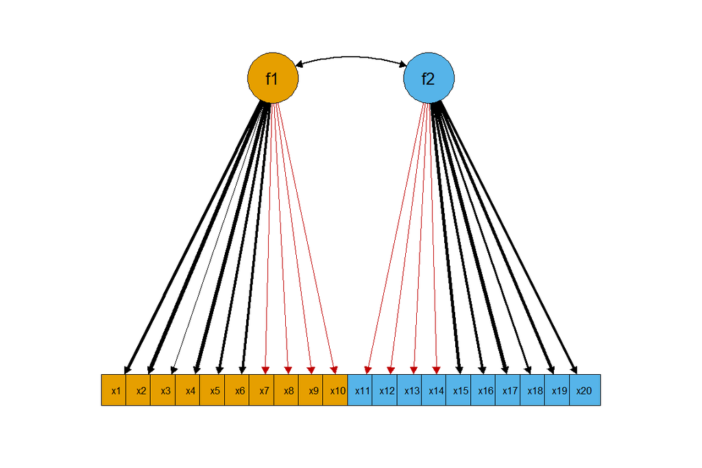

**Standardized Loading Across Folds**

[output not shown]

Note: loadings flagged when < 0.3 in a fold. ‘heywood flag’ is the number of folds the variable’s estimated residual variance was negative

**Mean Factor Correlations**

|  | f1 | f2 | flag |
| --- | --- | --- | --- |
| f1 | 1.00 |  | 0 |
| f2 | 0.19 | 1.00 | 0 |

Note: ‘flag’ is the number of folds the factor had a correlation > 0.9

**Scale Reliability Across Folds**

| factor | omega_h mean | omega_h range | omega_h flag | alpha mean | alpha range | alpha flag |
| --- | --- | --- | --- | --- | --- | --- |
| f1 | 0.69 | 0.65 - 0.72 | 0 | 0.68 | 0.63 - 0.72 | 0 |
| f2 | 0.63 | 0.54 - 0.69 | 1 | 0.60 | 0.47 - 0.67 | 1 |

Note: ‘flag’ is the number of folds the scale had a reliability < 0.6

# Appendix

## Within Fold Model Fit

| fold | 1-factor df | 1-factor chisq | 1-factor cfi | 1-factor rmsea | 2-factor df | 2-factor chisq | 2-factor cfi | 2-factor rmsea | 3-factor df | 3-factor chisq | 3-factor cfi | 3-factor rmsea | custom2f df | custom2f chisq | custom2f cfi | custom2f rmsea |
| --- | --- | --- | --- | --- | --- | --- | --- | --- | --- | --- | --- | --- | --- | --- | --- | --- |
| 1 | 170.00 | 522.77 | 0.53 | 0.10 | 169.00 | 345.07 | 0.76 | 0.07 | 167.00 | 182.51 | 0.98 | 0.02 | 169.00 | 358.72 | 0.75 | 0.07 |
| 2 | 170.00 | 487.95 | 0.42 | 0.09 | 169.00 | 357.22 | 0.66 | 0.07 | 167.00 | 193.97 | 0.95 | 0.03 | 169.00 | 409.98 | 0.56 | 0.08 |
| 3 | 170.00 | 460.60 | 0.49 | 0.09 | 169.00 | 302.03 | 0.77 | 0.06 | 167.00 | 142.19 | 1.00 | 0.00 | 169.00 | 331.66 | 0.72 | 0.07 |
| 4 | 170.00 | 399.25 | 0.61 | 0.08 |  |  |  |  | 167.00 | 171.19 | 0.99 | 0.01 | 169.00 | 312.77 | 0.76 | 0.06 |
| Mean | 170.00 | 467.64 | 0.51 | 0.09 | 169.00 | 334.77 | 0.73 | 0.07 | 167.00 | 172.47 | 0.98 | 0.01 | 169.00 | 353.28 | 0.69 | 0.07 |

## All EFA Structures

### Factors: 1

**Factor Structure Option 1**

**In Folds: 1, 2, 3, 4**

f1 =~ x1 + x2 + x3 + x4 + x5 + x6 + x7 + x8 + x9 + x10 + x11 + x12 + x13 + x14 + x15 + x16 + x17 + x18 + x19 + x20

### Factors: 2

**Factor Structure Option 1**

**In Folds: 1, 2, 3**

f1 =~ x1 + x2 + x3 + x4 + x5 + x6 + x7 + x8 + x9 + x10 + x11 + x12 + x13 + x14

f2 =~ x15 + x16 + x17 + x18 + x19 + x20

**Factor Structure Option 2**

**In Folds: 4**

f1 =~ x1 + x2 + x3 + x4 + x5 + x6 + x7 + x15 + x16 + x17 + x18 + x19 + x20

f2 =~ x8 + x9 + x10 + x11 + x12 + x13 + x14

### Factors: 3

**Factor Structure Option 1**

**In Folds: 1, 2, 3, 4**

f1 =~ x1 + x2 + x3 + x4 + x5 + x6 + x7

f2 =~ x15 + x16 + x17 + x18 + x19 + x20

f3 =~ x8 + x9 + x10 + x11 + x12 + x13 + x14

### Factors: 4

**Factor Structure Option 1**

**In Folds: 1, 2**

Structure contained single item factor

**Factor Structure Option 2**

**In Folds: 3**

f1 =~ x1 + x2 + x3 + x4 + x5 + x6 + x7

f2 =~ x15 + x16 + x17 + x19

f3 =~ x8 + x9 + x10 + x11 + x12 + x13

f4 =~ x14 + x18 + x20

**Factor Structure Option 3**

**In Folds: 4**

f1 =~ x1 + x2 + x3 + x4 + x5 + x6 + x7

f2 =~ x12 + x14

f3 =~ x8 + x9 + x10 + x11 + x13

f4 =~ x15 + x16 + x17 + x18 + x19 + x20

### Factors: 5

**Factor Structure Option 1**

**In Folds: 1, 2, 3, 4**

Structure contained single item factor